# Binomial data in R

## Analyzing proportions

Proportions give the fraction of the members of a population that possess a particular trait. We express these the same wayas probabilities, from 0.0–1.0.

**The binomial test allows us to determine the probability of an event that has a binomial distribution, meaning that each individual can have one of two possible outcomes** (e.g., success/failure, alive/dead, vertebrate/invertebrate, etc.). We state what we count as a “hit” or a trial with a particular outcome. For example, “What’s the probability that I would have 12 women in a class of 20?” A “hit” here would be observing a woman rather than a guy.

## The binomial equation

To calculate binomial probabilities, we use this equation:

Pr[X hits] $=\binom{n}{X}p^{X}(1-p^{n-X})$

Going forward, we’ll see that every test as assumptions that have to be true about your data to prevent you from “cheating” the test. The binomial test requires that:

1. the number of trials (*n*) is fixed
2. each trial is independent of every other trial
3. the probability of success (or a “hit”) is the same in every trial

The hand calculation is a bit of a chore, but the good news is that R has an easy way to calculate the probability of a single event using the function **dbinom()**. It has the general form of

```
dbinom(n, size, prob)
```

where n is the number of hits, size is the number of trials, and prob is the probability of a hit. Note that the in the hand equation *X* is the number of hits but R uses n. Sorry.

#### An example

I have a class in which 80% of my students are biology majors and 20% are chemistry majors. I wanted to know if I sampled students from this class, what would be the probability of selecting 2 chemistry majors and 3 biology majors if I selecting them in groups of 5.

I’ll call getting a bio major to be a hit for the purposes of this example. So, in this case, **p** = 0.8, **n** = 5, and **X** = 3, which gives me this:

```
dbinom(3, size = 5, prob = 0.8)

[1] 0.2048

(Note that R console output leads with the [1]. The result follows the [1] the way that your functions follow the >.)
```

So, I would have about a 20.5% chance of selecting 3 bio majors from this group if I sampled them in groups of 5.

What if I wanted to know the probability of getting 3 or more bio majors in groups of 5? This would be

Pr[3 or more] = Pr[3] + Pr[4] + Pr[5]

So, you could do the **dbinom()** function two more times and sum them:

```r
dbinom(4, size = 5, prob = 0.8)
```

```
## [1] 0.4096
```

```r
dbinom(5, size = 5, prob = 0.8)
```

```
## [1] 0.32768
```

Pr[3 or more] = 0.21 + 0.41 + 0.33 = 0.95. This means that I’d expect to get 3 or more bio majors 95% of the time with repeated sampling.

Or you could use this:

```r
# calculate the number of hits from 3 to 5
xsuccesses <- 3:5

# do each calculation
probx <- dbinom(xsuccesses, size = 5, prob = 0.8)

# make a table from those two values
probTable <- data.frame(xsuccesses, probx)

# display the table
show(probTable )
```

```
##   xsuccesses   probx
## 1          3 0.20480
## 2          4 0.40960
## 3          5 0.32768
```

Following these functions, you could also show the outcomes as a histogram:

`barplot(height = probx, names.arg = xsuccesses, space = 0, las = 1, ylab = "Probability", xlab = "Number of biology majors“)`

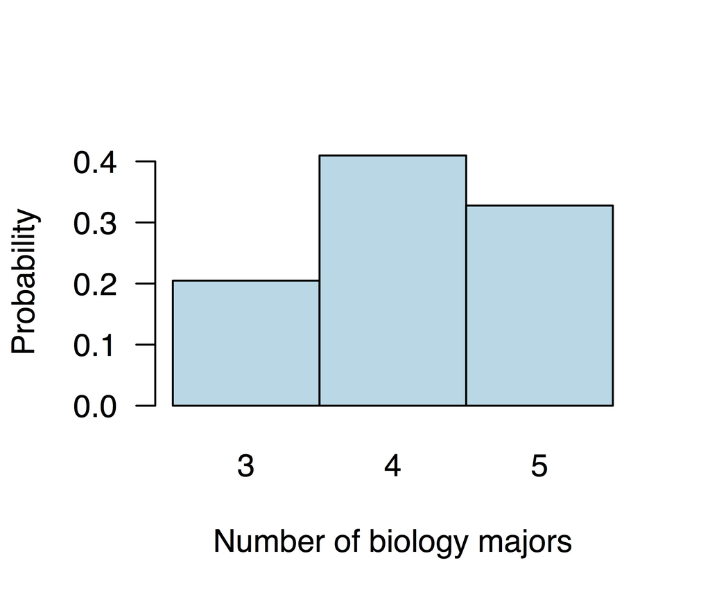

(I know that we’re using the barplot function to make a histogram, but this works better for binomial data based on the way that we calculated the objects.)

## Testing hypotheses with the binomial test

We use the binomial test to calculate the probabilities of a outcome to see if they differ from what we would expect to see by chance. For example:

Over the last 10 years, I have worked with 50 students in my research lab. This year I have 6 but only one is a guy. Is this a fluke? Should I have a more balanced sex distribution in my lab? Looking at my old class rosters, I found that 72% of the students who have taken my classes were women (actual data here, FYI.). So, Pr[guys] = 0.28. Overall, 10 of the 50 students in my lab have been guys.

**Question: Is the sex ratio in my lab (0.20) smaller than the average proportion of guys at Suffolk (0.28)?** Let’s use $\alpha$= 0.05 as our rejection level.

**Hypotheses:**

$H_0$: The sex ratio in my lab includes the same or greater proportion of guys than the CAS overall (put another way, Pr[11 or more] ≥ 0.05).

$H_a$: The sex ratio of my lab includes fewer guys than would be expected (or Pr[10 or fewer] < 0.05).

Adapting the code above:

```r
# calculate the number of hits from 0 to 10
xsuccesses <- 0:10

# do each calculation
probx <- dbinom(xsuccesses, size = 50, prob = 0.28)

# make a table from those two values
probTable <- data.frame(xsuccesses, probx)

# display the table
probTable
```

```
##    xsuccesses        probx
## 1           0 7.355714e-08
## 2           1 1.430278e-06
## 3           2 1.362737e-05
## 4           3 8.479251e-05
## 5           4 3.874547e-04
## 6           5 1.386227e-03
## 7           6 4.043161e-03
## 8           7 9.883283e-03
## 9           8 2.065881e-02
## 10          9 3.749191e-02
## 11         10 5.977877e-02
```

```r
sum(probx)  # Use this function to sum up those probabilities
```

```
## [1] 0.1337295
```

So, given the proportion of guys at Suffolk I would expect this proportion of guys in my lab (20% or fewer) at least 13% of the time. I fail to reject the null hypothesis because the calculated probability is greater than my confidence level of 0.05. I conclude, then, that my lab’s sex ratio is not significantly different than the sex ratio of students in my classes overall.

If you don’t need all the individual probabilities for plotting them, there’s an even shorter way to do this test:

```r
binom.test(10, n = 50, p = 0.28, alternative = "less")
```

```
##
##  Exact binomial test
##
## data:  10 and 50
## number of successes = 10, number of trials = 50, p-value = 0.1337
## alternative hypothesis: true probability of success is less than 0.28
## 95 percent confidence interval:
##  0.0000000 0.3155961
## sample estimates:
## probability of success
##                    0.2
```

Notice with this approach:

1. This function does a two-tailed test by default, but I added the argument alternative = “less” to specify that I only cared about 10 or fewer, not 10 or fewer AND 40 or more, which would be the two-tailed test. Refer to the help in RStudio for binom.test() for the arguments.
2. This reports my sample probability as 0.2.
3. This also calculates the 95% confidence interval of the sample estimate for me without any extra work.

## Sampling distribution of a proportion

Like any estimate, the sample proportion phat is an estimate of the population proportion p. One upshot of this is that we can calculate the 95% confidence interval. You could calculate the standard error of *p* and the 95% confidence interval by hand, but why should you? R to the rescue!

If you used **binom.test()** as before, you got the 95% CI in the output. Sometimes we need to estimate the parametric proportion, and that requires a fix called the Agresti-Coull method, discussed in Whitlock and Schluter.

To do this the easy way in R, you’ll need to download a package to add to base R. You’ll only need to install this package once per computer.

```
install.packages("binom", dependencies = TRUE)
```

With that installed, load the package so that you can use its functions. You’ll need to load the package in each R session if you want to use its commands:

```r
# Load the binom package
library(binom)

# calculate the 95% CI
binom.confint(10, 50, method = "ac")
```

```
##          method  x  n mean     lower     upper
## 1 agresti-coull 10 50  0.2 0.1105025 0.3323061
```

The text refers to the Agresti-Coull method of calculating the 95% CI. The function above does that (using method = “ac”). The 95% CI is different from what we got for my lab example above because it estimates the value of the parametric *p* using the observed data rather than the was we did it above, using 0.28 as the parameter based on previous observations of students in classes.

If you use it without the method argument, R will return CIs based on 11 different methods.

```r
binom.confint(10, 50)
```

```
##           method  x  n      mean      lower     upper
## 1  agresti-coull 10 50 0.2000000 0.11050245 0.3323061
## 2     asymptotic 10 50 0.2000000 0.08912769 0.3108723
## 3          bayes 10 50 0.2058824 0.10116836 0.3171207
## 4        cloglog 10 50 0.2000000 0.10318339 0.3196686
## 5          exact 10 50 0.2000000 0.10030224 0.3371831
## 6          logit 10 50 0.2000000 0.11113040 0.3332899
## 7         probit 10 50 0.2000000 0.10792338 0.3279450
## 8        profile 10 50 0.2000000 0.10570710 0.3242950
## 9            lrt 10 50 0.2000000 0.10568422 0.3242911
## 10     prop.test 10 50 0.2000000 0.10502158 0.3414368
## 11        wilson 10 50 0.2000000 0.11243750 0.3303711
```

Why on Earth would you want such a pile of CIs? Each of these methods uses a slightly different algorithm and you might choose one over the other based on your data; or you might want to look for a consensus among different methods if your data are messy.

## Conclusion

Calculating direct probabilities using the binomial equation is a powerful tool for testing hypotheses for data that are “either this outcome or that one” binomial in nature. (A “powerful” test means that it has a good ability to distinguish real differences from those expected by chance.) Future tests will allow us to do more with observations of nominal-scale variables that are more than yes/no outcomes.